# [Styling Choropleth Maps](http://lisacharlotterost.github.io/2014/12/14/Styling-Choropleth-Maps%202/) recreated in R

Daniel Kirsch

January 11, 2015

**Update January 14, 2015:** As requested by [Ari Friedman](https://twitter.com/aribfriedman/status/555167149392932864) I am now projecting my maps. Thanks for the hint.

A few days ago Bradley Boehmke [recreated a graphic](http://rpubs.com/bradleyboehmke/weather_graphic) from Edward Tufte’s classic book Visual Display of Quantitative Information, 2nd Ed. (page 30). The implementation looked like a lot of yak shaving (especially for the annotations) but it’s still (or precisely because of that) a great piece.

Then yesterday I stumbled over [Lisa Charlotte Rost](http://www.lisacharlotterost.de/)’s [blog](http://lisacharlotterost.github.io/) and really liked the article and the accompanying visualization about [Styling Choropleth Maps](http://lisacharlotterost.github.io/2014/12/14/Styling-Choropleth-Maps%202/). You should go read that article now if you are interested in mapping. I’ll wait for you here… Welcome back! Where were we? So, I asked her how she created it and upon learning that the final graphic was put together in Illustrator I started wondering if this could be done with [R](http://www.r-project.org/) and [ggplot2](http://ggplot2.org/). Inspired by Bradley’s post I went to work.

*This is Lisa’s original image:*

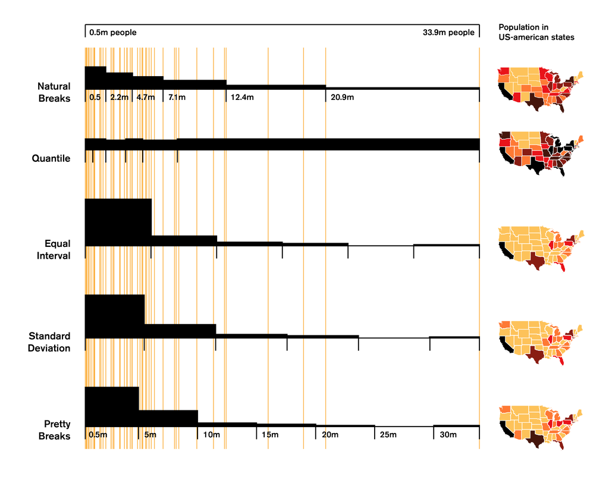

## R packages

```r
require(RCurl)
require(ggplot2)
require(grid)
require(gridExtra)
require(maps)
require(mapproj)
# require(RColorBrewer) # not really used - I thought i'd need it
require(classInt) # Jenks natural breaks
```

There are really no suprises here. I am using `RCurl` to download the data, `ggplot` and `maps` to draw histograms and… well… maps. There is only one package that I hadn’t used before and that is `classInt`. QGIS’ natural breaks coloring uses an algorithm by [George Jenks](http://en.wikipedia.org/wiki/Jenks_natural_breaks_optimization) which is to my good fortune implemented in that package. I was also thinking that I’d need `RColorBrewer` but Lisa seems to be using a sligtly treaked version of the [YlOrRd](http://colorbrewer2.org/) palette so I ended up just copying her colors into a manual color scale.

## Preparing the data

The first thing I did, was getting the state shapes from the `map` package and download the current [US census data](https://www.census.gov) from the web.

```r
states <- map_data("state")
population<- read.csv(textConnection(getURL('https://www.census.gov/popest/data/national/totals/2014/files/NST_EST2014_ALLDATA.csv')))[-(1:5),]
```

Next I calculated some descriptive statistics to help me with the task of cutting the range of population sizes into the different intervals needed for the QGIS styling modes described in Lisa’s article. I then computed the breaks of the intervals and added the information to which interval each state belongs to the `population` data frame via the very useful `cut` method.

```r
min = min(population$CENSUS2010POP)
max = max(population$CENSUS2010POP)
diff <- max - min
std = sd(population$CENSUS2010POP)

equal.interval = seq(min, max, by = diff/6)
quantile.interval = quantile(population$CENSUS2010POP, probs=seq(0, 1, by = 1/6))
std.interval = c(seq(min, max, by=std), max)
natural.interval = classIntervals(population$CENSUS2010PO, n = 6, style = 'jenks')$brks

population$population.equal = cut(population$CENSUS2010POP, breaks=equal.interval, include.lowest = TRUE)
population$population.quantile = cut(population$CENSUS2010POP, breaks=quantile.interval, include.lowest = TRUE)
population$population.std = cut(population$CENSUS2010POP, breaks=std.interval, include.lowest = TRUE)
population$population.natural = cut(population$CENSUS2010POP, breaks=natural.interval, include.lowest = TRUE)
```

Now every state (represented as a row in the `population` data frame) had not only it’s population (in the `CENSUS2010POP` column) associated to it but also the information which bucket it belongs to for the different styles. Here are the relevant fields of the first few rows.

```r
head(population[c('NAME', 'CENSUS2010POP', 'population.equal', 'population.quantile', 'population.std', 'population.natural')])
```

```
##          NAME CENSUS2010POP    population.equal population.quantile
## 6     Alabama       4779736 [5.64e+05,6.68e+06] (4.09e+06,5.99e+06]
## 7      Alaska        710231 [5.64e+05,6.68e+06] [5.64e+05,1.18e+06]
## 8     Arizona       6392017 [5.64e+05,6.68e+06] (5.99e+06,9.61e+06]
## 9    Arkansas       2915918 [5.64e+05,6.68e+06] (2.76e+06,4.09e+06]
## 10 California      37253956 (3.11e+07,3.73e+07] (9.61e+06,3.73e+07]
## 11   Colorado       5029196 [5.64e+05,6.68e+06] (4.09e+06,5.99e+06]
##         population.std  population.natural
## 6  [5.64e+05,7.33e+06] (2.06e+06,4.78e+06]
## 7  [5.64e+05,7.33e+06] [5.64e+05,2.06e+06]
## 8  [5.64e+05,7.33e+06]    (4.78e+06,8e+06]
## 9  [5.64e+05,7.33e+06] (2.06e+06,4.78e+06]
## 10 (3.44e+07,3.73e+07] (2.51e+07,3.73e+07]
## 11 [5.64e+05,7.33e+06]    (4.78e+06,8e+06]
```

Fortunately the `states` data frame had a field called `region` that closely matched the `name` field of our `population` data frame - just one of them was all lower case. Thus by adding another column using the right string transformation enabled me to `merge` (or you might be more familiar with the word *join* for this kind of operation) the two data frames. This gave me one big data frame with all the information I needed to create the histograms on the left of Lisa’s graphic and also the maps.

```r
population$region = tolower(population$NAME)
choro <- merge(states, population, sort = FALSE, by = "region")
choro <- choro[order(choro$order), ]
```

## Creating the visualization

Now that the data was available it was pretty easy to get started with the vizualization. `ggplot2` is just awesome to get going fast. The next graph shows a plot of the population distribution:

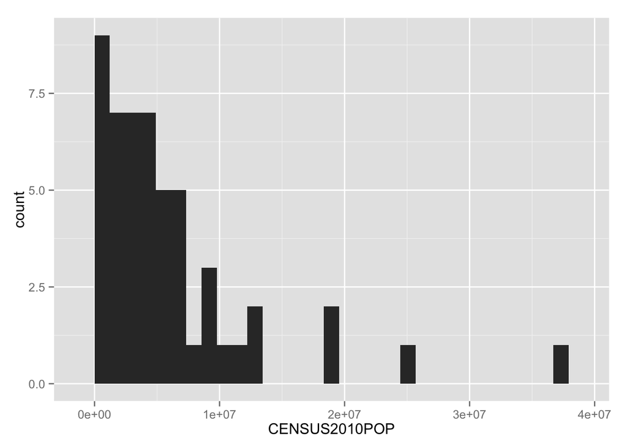

```r
ggplot(population, aes(x=CENSUS2010POP)) + geom_histogram()
```

It was easy to use one of the interval lists for the QGIS styles as breaks for the histogram with only minor modifications:

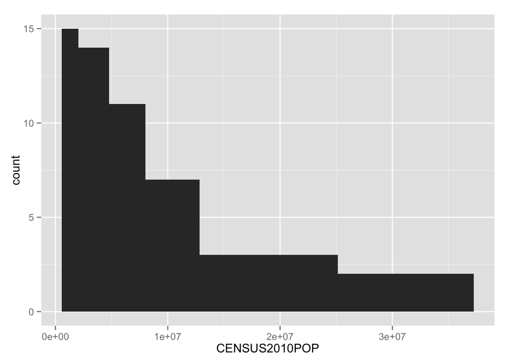

```r
ggplot(population, aes(x=CENSUS2010POP)) + geom_histogram(breaks=natural.interval, stat='bin')
```

And now I had to add the vertical lines indicating the data points:

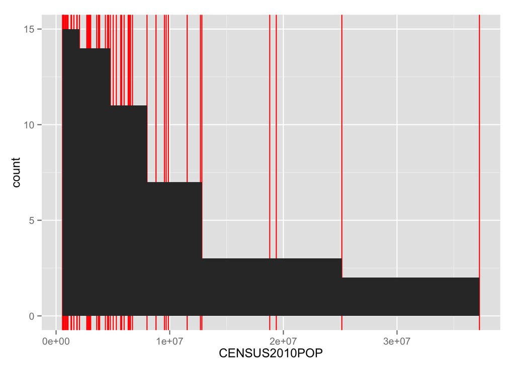

```r
ggplot(population, aes(x=CENSUS2010POP)) + geom_vline(aes(xintercept=CENSUS2010POP), color='red') + geom_histogram(breaks=natural.interval)
```

The map was equally easy to generate in it’s basic form:

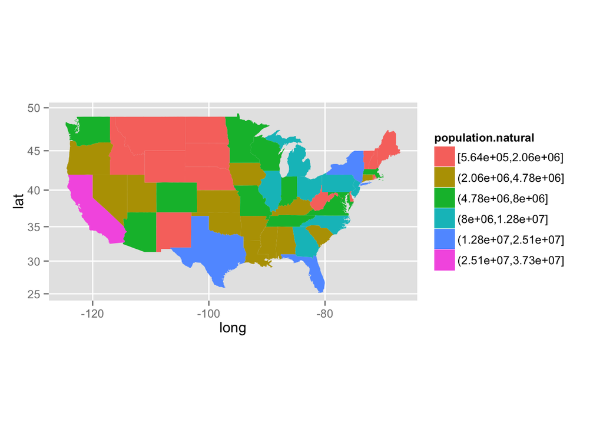

```r
ggplot(choro) + geom_polygon(aes(x=long, y=lat, group=group, fill=population.natural)) + coord_map()
```

Now all I had to do was to combine all the bits and pieces into a unit and tweak the look until I was happy. I should have expected it: This was actually the most tedious part. Therefore I’ll guide you through my final solution now instead of taking you on the journey of my struggles.

### Final solution

The next snipped was actually one of the last bit of code that I wrote. It creates a stripped down theme without borders, grid and axes so that I am able to match Lisa’s style.

```r
common.theme = theme(axis.line = element_blank(),
    panel.grid.major = element_blank(),
    panel.grid.minor = element_blank(),
    panel.border = element_blank(),
    panel.background = element_blank(),
    plot.title=element_blank(),
    axis.text.x=element_blank(),
    axis.title.x=element_blank(),
    axis.ticks.x=element_blank(),
    axis.title.y=element_text(size=10, face='bold'),
    axis.text.y=element_blank(),
    axis.ticks.y=element_blank())
map.theme = common.theme + theme(axis.title.y=element_blank())
```

The color scheme was also created rather late in the process. Lisa uses a color scale that matches the [YlOrRd](http://colorbrewer2.org/) theme from Cynthia Brewer’s color scales very closely but it’s a little darker. Therefore I simply used a color picker ad copied her colors as hex calues to create my own color scale.

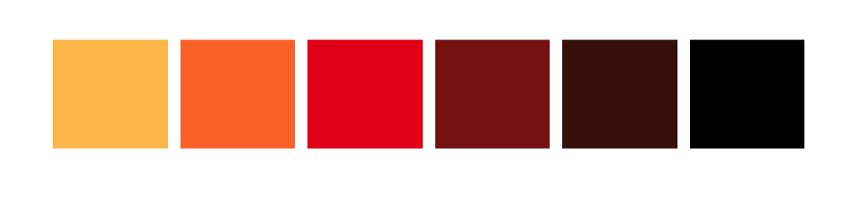

```r
colors <- c("#FDC25A", "#FD7834", "#E9151C", "#891E14", "#45150C", "#000000") # copied from lisa's maps - not exactly but close to YlOrRd
scale_fill_lisa <- scale_fill_manual(values=colors)
qplot(color, fill=color, data=data.frame(color=colors)) + scale_fill_lisa + guides(fill=FALSE) + common.theme + ylab(NULL)
```

To be able to join the different histograms in a way that the vertical lines look like the cover the whole graphic I had even more theming to do. Depending on where the graph was located in the layout I added a negative margin an the top, bottom or both.

```r
top.graph = theme(plot.margin = unit(c(0,.5,-.5,.5), "line"))
middle.graph = theme(plot.margin = unit(c(-.5,.5,-.5,.5), "line"))
bottom.graph = theme(plot.margin = unit(c(-.5,.5,.5,.5), "line"))
```

To still get a reasonable amount of whitespace between the histograms I hardcoded the y-scale.

```r
common.scale_y = scale_y_continuous(limits=c(0,60))
```

I created reusable fragments for the vertical lines indicating the states’ population data points and and the small black line segments at the bottom of each histogram.

```r
common.vline = geom_vline(aes(xintercept=CENSUS2010POP), color=colors[1], size=0.5)

interval_rug <- function(breaks) { return(geom_linerange(aes(x=CENSUS2010POP), ymin=-5, ymax=0, data=data.frame(CENSUS2010POP=breaks))) }
```

Finally everything was coming together into the actual hitograms. To not repeat myself too much I refactored the code into a function that assembles the histograms from just a few parameters.

```r
hist <- function(interval, position, label) {
  return(
     ggplot(population, aes(x=CENSUS2010POP)) +
       common.vline +
       geom_histogram(breaks=interval, fill='black', color='black') +
       geom_line(y=0) + # faux x-axis
       interval_rug(interval) +
       common.scale_y +
       position +
       common.theme +
       ylab(label)
  )
}

hist.equal <- hist(equal.interval, top.graph, "Equal Interval")
hist.quantile <- hist(quantile.interval, middle.graph, "Quantile")
hist.std <- hist(std.interval, middle.graph, "Std Deviation")
hist.natural <- hist(natural.interval, bottom.graph, "Natural Breaks")
```

I created a similar function for the maps. One new thing that I learned here was `aes_string` – apparently you can’t put a variable into an `aes(fill=...)` call.

```r
map <- function(cuts) {
  return(
    ggplot(choro) + geom_polygon(aes_string(y='lat', x='long', group='group', fill=cuts), color="white", size=.2) + scale_fill_lisa + guides(fill=FALSE) + map.theme + coord_map()
    )
}

map.equal <- map('population.equal')
map.quantile <- map('population.quantile')
map.std <- map('population.std')
map.natural <- map('population.natural')
```

By far the most ugly part of the whole endeavour was creating the header annotation in a way that looked reasonably similar to what Lisa had built. This reminded me about the feelings I had when reading Bradley Boehmke’s article and it brought Bret Victor’s [Drawing Dynamic Visualizations](https://vimeo.com/66085662) to my mind. Manipulating symbols is just not a nice way to do (information) design work - especially with a slow feedback loop like this. In the end I got reasonably close the the original.

```r
hist.title <- ggplot(data.frame(minmax=c(min,max)), aes(x=minmax)) +
  scale_y_continuous(limits=c(0,1)) +
  geom_blank() +
  geom_linerange(ymin=0, ymax=1, size=.5) +
  geom_line(y=1, size=.5) +
  common.theme +
  theme(plot.margin = unit(c(.5,.5,0,.5), "line")) + ylab('') +
  annotation_custom(grob=textGrob(label=paste(' ',format(min/1000000, digits=2),'m people'), just='left', gp=gpar(fontsize = 10, fontface='bold')), xmin=min, xmax=min) +
  annotation_custom(grob=textGrob(label=paste(format(max/1000000, digits=2),'m people '), just='right', gp=gpar(fontsize = 10, fontface='bold')), xmin=max, xmax=max)
```

Then I had to assemble everything into a single chart. This last snipped was also a piece of constant experimentation. Getting the width and height ratios right wasn’t exactly a fun exercise.

This is my final result.

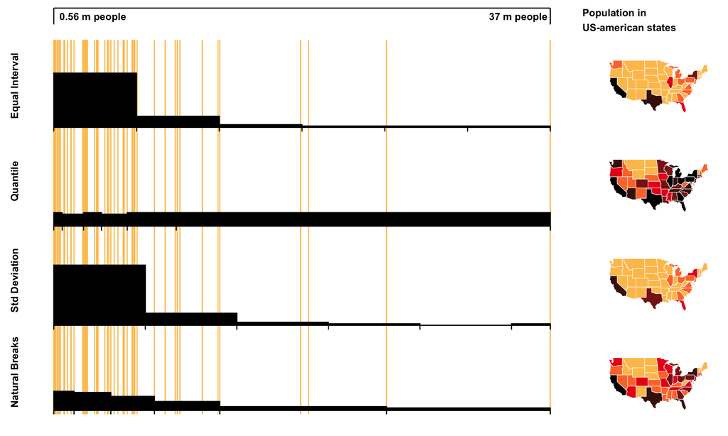

```r
grid.arrange(hist.title, textGrob(label="Population in\nUS-american states", just='left', x= unit(0, "npc"), gp=gpar(fontsize = 10, fontface='bold')),
             hist.equal, map.equal,
             hist.quantile, map.quantile,
             hist.std, map.std,
             hist.natural, map.natural,
             ncol=2, widths=c(4,1), heights=c(1.2,3,3,3,3))
```

## Conclusion

I am quite happy with the result. I proved to myself that it is possible to recreate Lisa’s graphic in R. While this was a fun exercise it was also a confirmation for myself (which didn’t come unexpected) that R is not the tool to *design* graphics. It’s awesome to get results fast. Exploring datasets with `ggplot2` is a bliss. Tweaking the visuals however took longer than getting the basic graphics done. Maybe preparing a basic graph in R and exporting to SVG is a viable solution? I haven’t done much research yet.

I hope you enjoyed the article and could learn a thing or two. Again a big shout out to [Lisa](http://www.lisacharlotterost.de/) for creating the original graphic and to [Bradley](http://rpubs.com/bradleyboehmke/weather_graphic) to inspire me to recreate it.

**Caveat:** You might have noticed that our histograms are looking a little confusing. That is because they don’t have a constant bin width and don’t make up for that in adapting the bar height. That means that not the area but only the bar height indicates how many data points are in a bucket. I think the graphic still succeeds making it’s point.

### Links

The following sources proved very useful during creating this graphic.

- http://stackoverflow.com/questions/15016995/how-to-align-multiple-ggplot2-plots-and-add-shadows-over-all-of-them
- http://www.cookbook-r.com/Graphs/Axes_(ggplot2)/